# De Silva_Exam 2

Sindupa De Silva

March 22, 2021

Included with this exam is a dataset called “Exam 2 Data.csv”, with the following variables: y: count of events x1: predictor variable, continuous x2: predictor variable, continuous x3: categorical variable with 3 levels: "a", "b", and "c"

1. Import this dataset into R and inspect the first several rows of your data

```r
Data <- read.csv('Exam 2 Data.csv')
head(Data)
```

```
##    y          x1          x2 x3
## 1  2  1.37034210 -0.66615843  b
## 2  2 -0.70417232 -0.03705622  c
## 3  4 -0.04223752 -1.53148692  c
## 4  9 -0.56711072 -0.06529335  b
## 5  1  0.31189773  0.81650472  a
## 6 13 -0.35994479 -0.80042308  b
```

2. Fit a Poisson model that assumes your response is a function of x1, x2, and x3. Include an interaction between x1 and x2 only (i.e., do not include an interaction between your categorical variables and any other variables).

```r
Fit <- glm(y ~ x1 * x2 + x3, family = poisson, data = Data)
summary(Fit)
```

```
##
## Call:
## glm(formula = y ~ x1 * x2 + x3, family = poisson, data = Data)
##
## Deviance Residuals:
##     Min       1Q   Median       3Q      Max
## -2.3620  -0.6973  -0.1007   0.5236   2.6779
##
## Coefficients:
##             Estimate Std. Error z value Pr(>|z|)
## (Intercept)  1.13258    0.08540  13.262  < 2e-16 ***
## x1          -1.03491    0.05019 -20.620  < 2e-16 ***
## x2          -0.90839    0.06977 -13.021  < 2e-16 ***
## x3b          0.37532    0.09246   4.059 4.92e-05 ***
## x3c         -0.88354    0.12072  -7.319 2.50e-13 ***
## x1:x2       -0.28868    0.05142  -5.614 1.98e-08 ***
## ---
## Signif. codes:  0 '***' 0.001 '**' 0.01 '*' 0.05 '.' 0.1 ' ' 1
##
## (Dispersion parameter for poisson family taken to be 1)
##
##     Null deviance: 720.551  on 99  degrees of freedom
## Residual deviance:  89.088  on 94  degrees of freedom
## AIC: 392.86
##
## Number of Fisher Scoring iterations: 5
```

3. Interpret the effect of variable x1 when x2 = -1

```r
# Extract the coefficients
betas <- coef(Fit)

# model for x1 when x2 = -1
betas[2] + betas[6] * -1
```

```
##         x1
## -0.7462245
```

```r
# create vectors of the data
# vector of x1 values
x1 <- seq(min(Data$x1), max(Data$x1), length.out = 100)

# x2 fixed at -1
x2 = -1

# vector of x2 values fixed at -1
x3 <- factor('a', levels = c('a', 'b', 'c'))

# Create a new data frame with all three variables
new.data <- data.frame(x1 = x1, x2 = x2, x3 = x3)

# Predict the new range of values
Pred <- predict.glm(Fit, new.data, type = 'link', se.fit = T)

# Calculate the low limits of our 95% confidence interval
low <- exp(Pred$fit + qnorm(0.025) * Pred$se.fit)
low
```

```
##          1          2          3          4          5          6          7
## 53.3276085 51.3710736 49.4843656 47.6649479 45.9103735 44.2182816 42.5863949
##          8          9         10         11         12         13         14
## 41.0125160 39.4945247 38.0303756 36.6180946 35.2557771 33.9415851 32.6737452
##         15         16         17         18         19         20         21
## 31.4505460 30.2703364 29.1315235 28.0325708 26.9719966 25.9483726 24.9603226
##         22         23         24         25         26         27         28
## 24.0065211 23.0856929 22.1966120 21.3381009 20.5090311 19.7083220 18.9349414
##         29         30         31         32         33         34         35
## 18.1879057 17.4662799 16.7691776 16.0957613 15.4452420 14.8168790 14.2099780
##         36         37         38         39         40         41         42
## 13.6238906 13.0580112 12.5117742 11.9846510 11.4761449 10.9857873 10.5131326
##         43         44         45         46         47         48         49
## 10.0577531  9.6192348  9.1971722  8.7911656  8.4008171  8.0257284  7.6654993
##         50         51         52         53         54         55         56
##  7.3197264  6.9880029  6.6699188  6.3650610  6.0730150  5.7933653  5.5256968
##         57         58         59         60         61         62         63
##  5.2695966  5.0246544  4.7904646  4.5666270  4.3527479  4.1484410  3.9533284
##         64         65         66         67         68         69         70
##  3.7670410  3.5892194  3.4195139  3.2575851  3.1031043  2.9557533  2.8152245
##         71         72         73         74         75         76         77
##  2.6812212  2.5534575  2.4316577  2.3155568  2.2049000  2.0994425  1.9989493
##         78         79         80         81         82         83         84
##  1.9031951  1.8119638  1.7250483  1.6422504  1.5633801  1.4882559  1.4167040
##         85         86         87         88         89         90         91
##  1.3485582  1.2836599  1.2218571  1.1630049  1.1069650  1.0536049  1.0027986
##         92         93         94         95         96         97         98
##  0.9544256  0.9083709  0.8645247  0.8227826  0.7830445  0.7452155  0.7092046
##         99        100
##  0.6749254  0.6422954
```

```r
# Calculate the high limits of our 95% confidence interval
high <- exp(Pred$fit + qnorm(0.975) * Pred$se.fit)
high
```

```
##         1         2         3         4         5         6         7         8
## 95.997360 91.401916 87.029899 82.870491 78.913400 75.148837 71.567491 68.160506
##         9        10        11        12        13        14        15        16
## 64.919456 61.836328 58.903501 56.113726 53.460107 50.936086 48.535426 46.252193
##        17        18        19        20        21        22        23        24
## 44.080745 42.015714 40.051992 38.184722 36.409282 34.721272 33.116504 31.590991
##        25        26        27        28        29        30        31        32
## 30.140935 28.762716 27.452881 26.208138 25.025339 23.901480 22.833685 21.819198
##        33        34        35        36        37        38        39        40
## 20.855381 19.939702 19.069730 18.243129 17.457659 16.711163 16.001575 15.326912
##        41        42        43        44        45        46        47        48
## 14.685273 14.074845 13.493895 12.940776 12.413924 11.911857 11.433178 10.976568
##        49        50        51        52        53        54        55        56
## 10.540789 10.124679  9.727150  9.347181  8.983823  8.636185  8.303438  7.984806
##        57        58        59        60        61        62        63        64
##  7.679564  7.387037  7.106592  6.837637  6.579617  6.332012  6.094335  5.866126
##        65        66        67        68        69        70        71        72
##  5.646955  5.436414  5.234119  5.039710  4.852844  4.673196  4.500460  4.334345
##        73        74        75        76        77        78        79        80
##  4.174575  4.020886  3.873030  3.730769  3.593876  3.462136  3.335342  3.213300
##        81        82        83        84        85        86        87        88
##  3.095820  2.982724  2.873840  2.769004  2.668060  2.570856  2.477250  2.387104
##        89        90        91        92        93        94        95        96
##  2.300284  2.216665  2.136125  2.058548  1.983821  1.911836  1.842492  1.775688
##        97        98        99       100
##  1.711330  1.649327  1.589590  1.532035
```

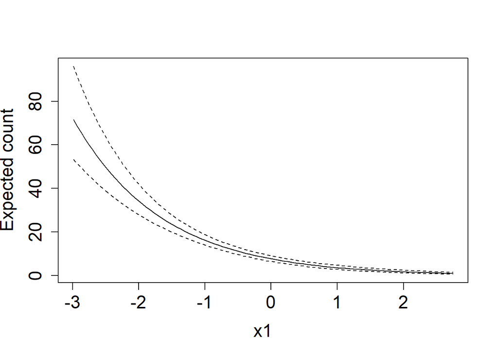

```r
# visualizing the predicted values with the high and low confidence intervals
plot(y = exp(Pred$fit), x = new.data$x1, xlab = 'x1',
     ylab = 'Expected count', cex.axis = 1.5, cex.lab = 1.5,
     ylim = c(min(low), max(high)), type = 'l')
lines(x = new.data$x1, y = low, lty = 2)
lines(x = new.data$x1, y = high, lty = 2)
```

5. Interpret the effect of variable x3

```r
# Retrieve model coeficients
summary (Fit)
```

```
##
## Call:
## glm(formula = y ~ x1 * x2 + x3, family = poisson, data = Data)
##
## Deviance Residuals:
##     Min       1Q   Median       3Q      Max
## -2.3620  -0.6973  -0.1007   0.5236   2.6779
##
## Coefficients:
##             Estimate Std. Error z value Pr(>|z|)
## (Intercept)  1.13258    0.08540  13.262  < 2e-16 ***
## x1          -1.03491    0.05019 -20.620  < 2e-16 ***
## x2          -0.90839    0.06977 -13.021  < 2e-16 ***
## x3b          0.37532    0.09246   4.059 4.92e-05 ***
## x3c         -0.88354    0.12072  -7.319 2.50e-13 ***
## x1:x2       -0.28868    0.05142  -5.614 1.98e-08 ***
## ---
## Signif. codes:  0 '***' 0.001 '**' 0.01 '*' 0.05 '.' 0.1 ' ' 1
##
## (Dispersion parameter for poisson family taken to be 1)
##
##     Null deviance: 720.551  on 99  degrees of freedom
## Residual deviance:  89.088  on 94  degrees of freedom
## AIC: 392.86
##
## Number of Fisher Scoring iterations: 5
```

6. Use contrasts to evaluate the null hypothesis that the difference in log expected count between levels "b" and "c" = 0. Fix x1 and x2 at their means.

```r
# Create vectors of x1 and x2 fixed at their mean
# x1 <- seq(min(mean(Data$x1)), max(mean(Data$x1)), length.out = 100)
# x2 <- seq(min(mean(Data$x2)), max(mean(Data$x2)), length.out = 100)
# x3 <- Data$x3
# y  <- Data$y
# new.data <- data.frame(y = y, x1 = x1, x2 = x2 , x3 = x3)

# Run new model
# fit <- glm(y ~ x1 * x2 + x3, family = poisson, data = new.data)
# summary(fit)
# betas <- coef(fit)


# Tried doing this above, and then switched to this route..

library(multcomp)
# create a contrast matrix
x <- matrix(c(0, 0, 0, 1, 1, 0), nrow = 1) # Contrast matrix

cnt <- glht(Fit, x)
summary(cnt, test = adjusted('none'))
```

```
##
##   Simultaneous Tests for General Linear Hypotheses
##
## Fit: glm(formula = y ~ x1 * x2 + x3, family = poisson, data = Data)
##
## Linear Hypotheses:
##        Estimate Std. Error z value Pr(>|z|)
## 1 == 0  -0.5082     0.1787  -2.845  0.00445 **
## ---
## Signif. codes:  0 '***' 0.001 '**' 0.01 '*' 0.05 '.' 0.1 ' ' 1
## (Adjusted p values reported -- none method)
```

7. Derive the test statistic and p-value associated with the interaction between x1 and x2. What is the null hypothesis? Do we reject or fail to reject this null hypothesis? Defend your answer.

```r
# Standard error
Std.e <- summary(Fit)[['coefficients']][, 2]

# test statistic
betas[6] / Std.e[6]
```

```
##     x1:x2
## -5.614074
```

```r
# p-value
pnorm(-1 * abs(betas[6] / Std.e[6])) * 2
```

```
##        x1:x2
## 1.976182e-08
```

For the interaction of x1 and x2 The null hypothesis is β6 = 0. Based on the derived p-value (<0.05) we reject the null hypothesis, therefore we can say there is evidence that the effect of variable x1 depends on the level of x2.

8. Assume you have the following realizations of random variable Y : y = (1, 0) Further assume realizations of the random variable Y are Bernoulli distributed: y ∼ Bernoulli(p). What is the probability of observing each of these random variables assuming the log odds of success = -2?

```r
dpois(c(1,0), plogis(-2))
```

```
## [1] 0.1058078 0.8876277
```

9. What is the "support" of a Bernoulli random variable? What are the acceptable values of it’s sole parameter? To which quantity do we apply a link function, and why do we do this? What is the principle link function we use in binomial (i.e., logistic) regression, and what it it’s inverse function?

Bernoulli random variables represent values of "0" or "1", and we apply the link function to the values of the variable itself because it allows us to transform and bind the "0" and "1" values into the real number line. Log() and exp().

10. What is a fundamental assumption we make to derive inference when comparing two levels of a categorical random variable?

We assume that the linear combination of the variables are gaussian.